# Xử lý số liệu thống kê - FIFA Data

#### 3.4.4 Biểu đồ hồi quy

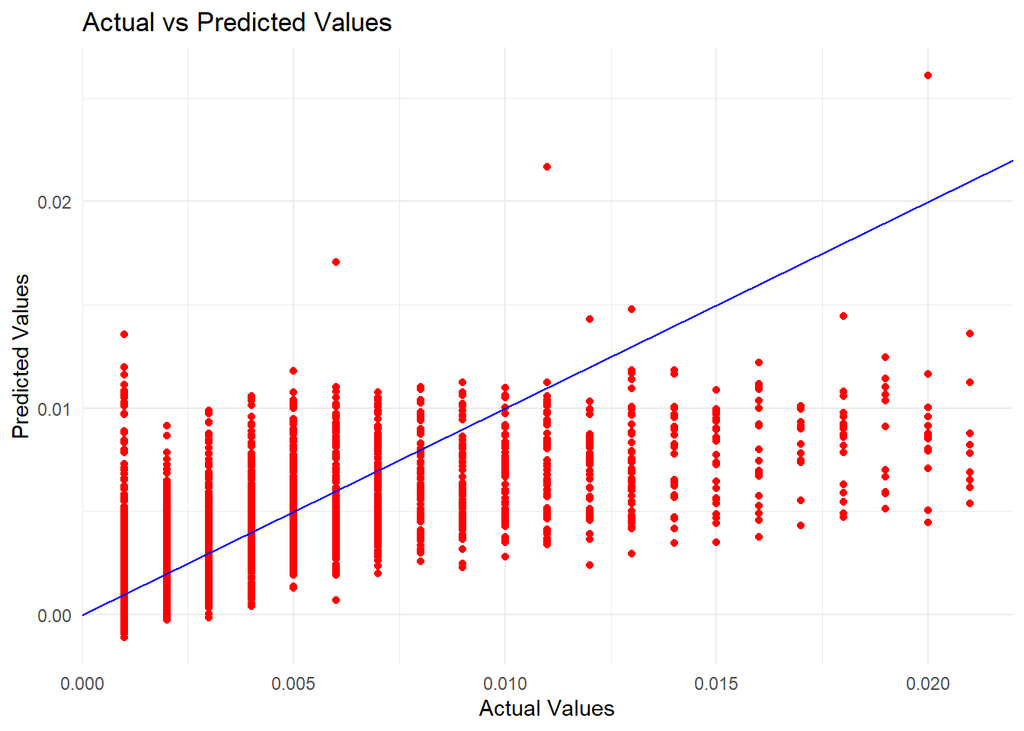

```r
# Dự đoán với mô hình mới
defender_predict_wage <- predict(defender_model_final, newdata = df_defender_numeric)

# Vẽ biểu đồ dự đoán so với giá trị thực tế
result <- data.frame(actual_values = df_defender_numeric$wage, predictions = defender_predict_wage)

ggplot(result, aes(x = actual_values, y = predictions)) +
  geom_point(color = "red") +
  geom_abline(slope = 1, intercept = 0, color = "blue") +
  labs(
    title = "Actual vs Predicted Values",
    x = "Actual Values",
    y = "Predicted Values"
  ) +
  theme_minimal()
```

**Nhận xét**: Đường thẳng hồi quy không quá khớp với dữ liệu.

#### 3.4.5 Một số chuẩn đoán cho mô hình

##### Kiểm định tuyến tính mô hình

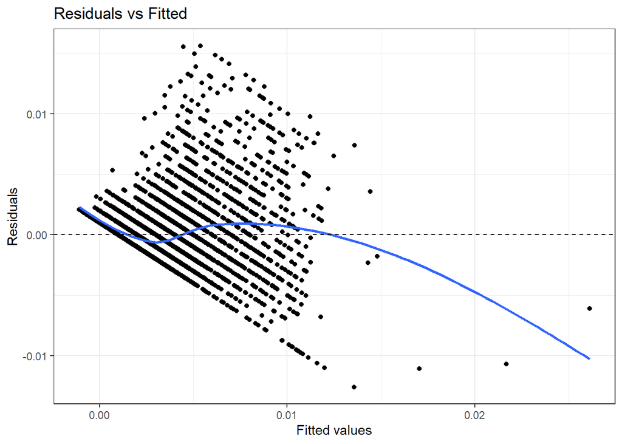

**Nhận xét**: Hình vẽ cho thấy xu hướng đường cong

=> Giả định về tuyến tính của mô hình là chưa phù hợp

##### Kiểm đinh đồng nhất phương sai

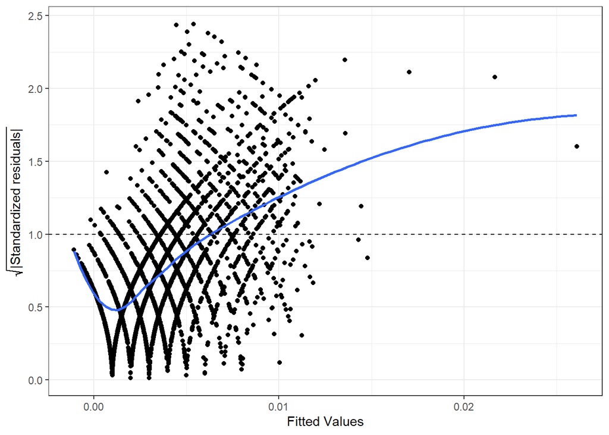

**Nhận xét**: Đồ thị dường như không xấp xỉ đường thẳng 1

=> Giả định về phương sai đồng nhất là chưa hợp lý

##### Kiểm tra đa cộng tuyến

```r
vif(defender_model_final)
```

```
##                      age                potential                    value
##                 3.566152                 3.067159                 4.620813
## international_reputation              skill_moves                body_type
##                 1.137893                 1.455573                 1.058560
##                 crossing         heading_accuracy                    curve
##                 2.591555                 2.104409                 2.878569
##               shot_power                  stamina               long_shots
##                 2.569665                 1.374757                 3.128794
##            interceptions                penalties           sliding_tackle
##                 2.582244                 1.563571                 2.261635
##           release_clause
##                 3.274344
```

**Nhận xét**: Mô hình không xảy ra đa cộng tuyến.

#### 3.4.6 Đánh giá mô hình

##### RMSE của mô hình

```r
# Đánh giá mô hình với tập kiểm tra
set.seed(5)  # Để tái tạo kết quả

# Chia dữ liệu thành tập huấn luyện và kiểm tra (80% huấn luyện, 20% kiểm tra)
train_index <- sample(seq_len(nrow(df_defender_numeric)), size = 0.8 * nrow(df_defender_numeric))
train_data <- df_defender_numeric[train_index, ]
test_data <- df_defender_numeric[-train_index, ]

# Tạo công thức mô hình với các biến đã chọn
defender_formula_final <- as.formula(paste("wage ~", paste(defender_best_vars, collapse = "+")))

# Huấn luyện mô hình hồi quy tuyến tính
defender_model_final <- lm(defender_formula_final, data = train_data)

# Dự đoán trên tập kiểm tra
defender_predictions <- predict(defender_model_final, newdata = test_data)

# Tính toán RMSE trên tập kiểm tra
actual_values <- test_data$wage
rmse <- sqrt(mean((actual_values - defender_predictions)^2))
print(paste("RMSE từ tập kiểm tra: ", rmse))
```

```
## [1] "RMSE từ tập kiểm tra:  0.00251190264596087"
```

#### R2 Score

```r
ss_total <- sum((actual_values - mean(actual_values))^2)  # SS_tot
ss_residual <- sum((actual_values - defender_predictions)^2)  # SS_res
r_squared <- 1 - (ss_residual / ss_total)
print(paste("R^2 từ tập kiểm tra: ", r_squared))
```

```
## [1] "R^2 từ tập kiểm tra:  0.469054815869114"
```

#### Áp dụng k-fold validation để tính RMSE

```r
# Áp dụng K-Fold CV với k = 5
k <- 5
k_fold_result <- k_fold_cv(df_defender_numeric, defender_formula_final, k)
```

```
## [1] "RMSE từ K-Fold CV (k = 5 ): 0.00256307506915486"
```

#### 3.4.7 Mở rộng mô hình

##### Khởi tạo mô hình

Ta sẽ tiến hành chạy mô hình bậc 2 với các biến có ít độ tuyến tính với mô hình

```r
coeffs <- summary(defender_model_final)$coefficients

if (is.matrix(coeffs)) {
  p_values <- coeffs[, "Pr(>|t|)"]
} else {
  # Khi chỉ có một biến độc lập
  p_values <- coeffs["Pr(>|t|)"]
}

# Loại bỏ hệ số intercept (nếu cần)
p_values <- p_values[-1]  # Loại bỏ dòng đầu tiên (Intercept)

# Phân loại biến theo p-value
defender_2 <- names(p_values[p_values > 0.05])  # Biến có p-value > 0.05
defender_1 <- names(p_values[p_values <= 0.05]) # Biến có p-value <= 0.05

defender_best_vars_1 <- defender_best_vars[defender_best_vars %in% defender_1]
defender_best_vars_2 <- defender_best_vars[defender_best_vars %in% defender_2]

# Tạo công thức hồi quy bậc hai từ các biến trong defender_best_vars
defender_formula_final <- as.formula(paste(
  "wage ~",
  paste(defender_best_vars_1, collapse = "+"),
  "+",
  paste(paste0("I(", defender_best_vars_2, "^2)"), collapse = "+")
))

# Chạy mô hình hồi quy bậc hai với các biến đã chọn
defender_model_final <- lm(defender_formula_final, data = df_defender_numeric)
```

```r
# In kết quả của mô hình
summary(defender_model_final)
```

```
##
## Call:
## lm(formula = defender_formula_final, data = df_defender_numeric)
##
## Residuals:
##        Min         1Q     Median         3Q        Max
## -0.0127684 -0.0013828 -0.0003670  0.0008296  0.0156789
##
## Coefficients:
##                            Estimate Std. Error t value Pr(>|t|)
## (Intercept)              -7.772e-03  1.110e-03  -6.999 2.95e-12 ***
## age                       1.629e-04  1.573e-05  10.360  < 2e-16 ***
## potential                 3.275e-05  1.436e-05   2.281 0.022581 *
## value                     1.972e-03  1.578e-04  12.496  < 2e-16 ***
## international_reputation  1.005e-03  2.745e-04   3.663 0.000252 ***
## skill_moves               4.052e-04  1.323e-04   3.063 0.002207 **
## heading_accuracy          1.764e-05  6.151e-06   2.868 0.004154 **
## shot_power               -1.290e-05  4.585e-06  -2.813 0.004922 **
## stamina                  -2.440e-05  4.449e-06  -5.484 4.38e-08 ***
## interceptions            -2.354e-05  9.343e-06  -2.519 0.011789 *
## penalties                 1.271e-05  4.952e-06   2.567 0.010287 *
## sliding_tackle            4.220e-05  9.965e-06   4.235 2.34e-05 ***
## release_clause            7.557e-04  5.929e-05  12.746  < 2e-16 ***
## I(body_type^2)           -4.193e-06  1.850e-06  -2.267 0.023443 *
## I(crossing^2)             8.544e-08  4.308e-08   1.983 0.047406 *
## I(curve^2)                9.036e-08  5.073e-08   1.781 0.074930 .
## I(long_shots^2)           1.507e-07  5.817e-08   2.590 0.009623 **
## ---
## Signif. codes:  0 '***' 0.001 '**' 0.01 '*' 0.05 '.' 0.1 ' ' 1
##
## Residual standard error: 0.002621 on 4572 degrees of freedom
## Multiple R-squared:  0.4521, Adjusted R-squared:  0.4502
## F-statistic: 235.8 on 16 and 4572 DF,  p-value: < 2.2e-16
```

##### Đường thẳng hồi quy

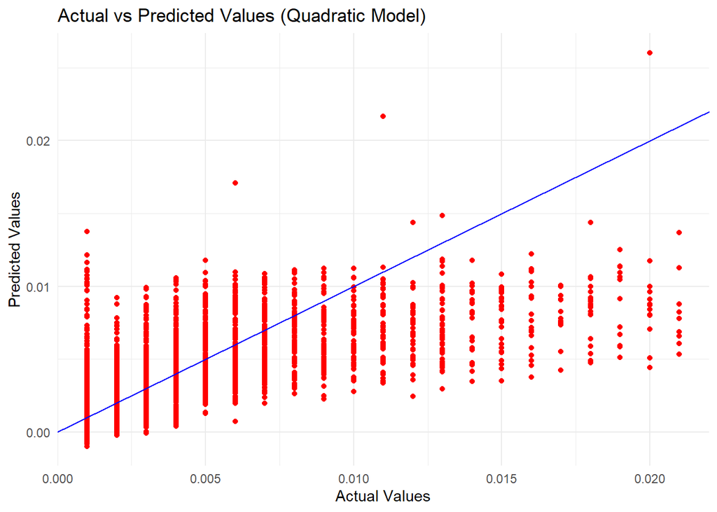

##### Đánh giá mô hình

```
## [1] "RMSE từ tập kiểm tra (Quadratic Model):  0.00248485185854343"
```

```
## [1] "R2 Score từ tập kiểm tra (Quadratic Model):  0.48042878389994"
```

**Nhận xét**: Mô hình bậc 2 có kết quả chạy tốt hơn, với R2 Score cao hơn và RMSE thấp hơn.